# Analytics Edge: Unit 1 - Stocks Dynamics

Antonella Schiavoni

# Download and read the following files into R, using the read.csv function

```r
IBM = read.csv("IBMStock.csv")
GE = read.csv("GEStock.csv")
ProcterGamble = read.csv("ProcterGambleStock.csv")
CocaCola = read.csv("CocaColaStock.csv")
Boeing = read.csv("BoeingStock.csv")
```

# Problem 1.1 - Summary Statistics

We need to convert the dates into a format that R can understand. Right now, the date variable is stored as a factor. We can convert this to a “Date” object in R.

```r
IBM$Date = as.Date(IBM$Date, "%m/%d/%y")

GE$Date = as.Date(GE$Date, "%m/%d/%y")

CocaCola$Date = as.Date(CocaCola$Date, "%m/%d/%y")

ProcterGamble$Date = as.Date(ProcterGamble$Date, "%m/%d/%y")

Boeing$Date = as.Date(Boeing$Date, "%m/%d/%y")
```

# Problem 1.2 - Summary Statistics

What is the earliest year in our datasets?

```r
min(IBM$Date)
```

```
[1] "1970-01-01"
```

```r
min(GE$Date)
```

```
[1] "1970-01-01"
```

```r
min(CocaCola$Date)
```

```
[1] "1970-01-01"
```

```r
min(ProcterGamble$Date)
```

```
[1] "1970-01-01"
```

```r
min(Boeing$Date)
```

```
[1] "1970-01-01"
```

# Problem 1.3 - Summary Statistics

What is the latests year in our datasets?

```r
max(IBM$Date)
```

```
[1] "2009-12-01"
```

```r
max(GE$Date)
```

```
[1] "2009-12-01"
```

```r
max(CocaCola$Date)
```

```
[1] "2009-12-01"
```

```r
max(ProcterGamble$Date)
```

```
[1] "2009-12-01"
```

```r
max(Boeing$Date)
```

```
[1] "2009-12-01"
```

# Problem 1.4 - Summary Statistics

What is the mean stock price of IBM over this time period?

```r
mean(IBM$StockPrice)
```

```
[1] 144.375
```

# Problem 1.5 - Summary Statistics

What is the minimum stock price of General Electric (GE) over this time period?

```r
min(GE$StockPrice)
```

```
[1] 9.293636
```

# Problem 1.6 - Summary Statistics

What is the maximum stock price of Coca-Cola over this time period?

```r
max(CocaCola$StockPrice)
```

```
[1] 146.5843
```

# Problem 1.7 - Summary Statistics

What is the median stock price of Boeing over this time period?

```r
median(Boeing$StockPrice)
```

```
[1] 44.8834
```

# Problem 1.8 - Summary Statistics

What is the standard deviation of the stock price of Procter & Gamble over this time period?

```r
sd(ProcterGamble$StockPrice)
```

```
[1] 18.19414
```

# Problem 2.1 - Visualizing Stock Dynamics

Let’s plot the stock prices to see if we can visualize trends in stock prices during this time period. Using the plot function, plot the Date on the x-axis and the StockPrice on the y-axis, for Coca-Cola.

Around what year did Coca-Cola has its highest stock price in this time period?

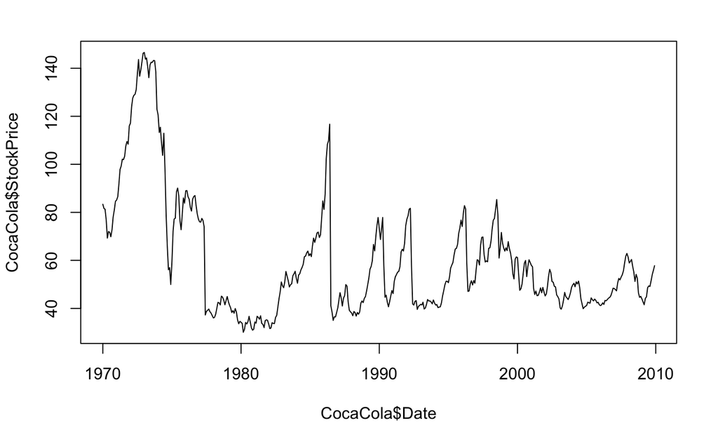

Around 1973 CocaCola shows the highest stock price. Around 1980 CocaCola shows the lowest stock price

# Problem 2.2 - Visualizing Stock Dynamics

Now, let’s add the line for Procter & Gamble too. You can add a line to a plot in R by using the lines function instead of the plot function.

In March of 2000, the technology bubble burst, and a stock market crash occurred. According to this plot, which company’s stock dropped more?

```r
plot(CocaCola$Date, CocaCola$StockPrice, type='l', col='red')
lines(ProcterGamble$Date, ProcterGamble$StockPrice, col='blue')
```

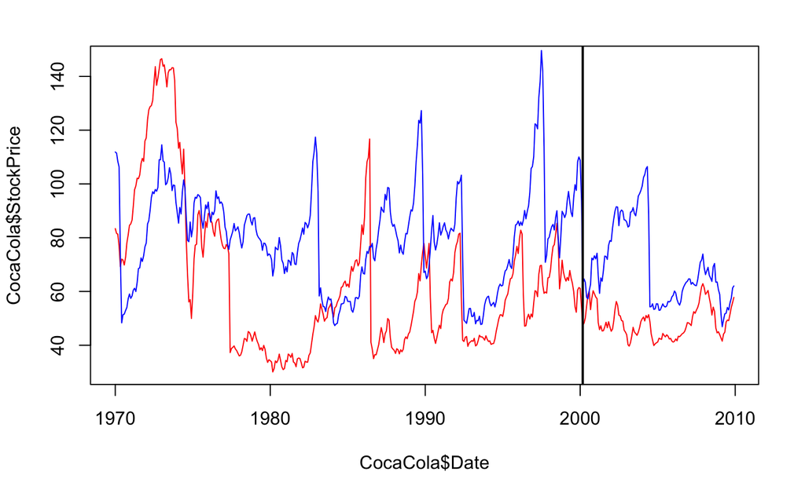

```r
abline(v=as.Date(c("2000-03-01")), lwd=2)
```

Both lines drop, but Procter and Gamble drops more.

# Problem 2.3 - Visualizing Stock Dynamics

Around 1983, the stock for one of these companies (Coca-Cola or Procter and Gamble) was going up, while the other was going down. Which one was going up? CocaCola

In the time period shown in the plot, which stock generally has lower values? CocaCola

# Problem 3.1 - Visualizing Stock Dynamics 1995-2005

Which stock fell the most right after the technology bubble burst in March 2000?

```r
plot(CocaCola$Date[301:432], CocaCola$StockPrice[301:432], type="l", col="red", ylim=c(0,210), xlab = "Date", ylab = "Stock Price")
lines(ProcterGamble$Date[301:432], ProcterGamble$StockPrice[301:432], col="blue")
```

```r
lines(IBM$Date[301:432], IBM$StockPrice[301:432], col="green")
lines(GE$Date[301:432], GE$StockPrice[301:432], col="purple")
```

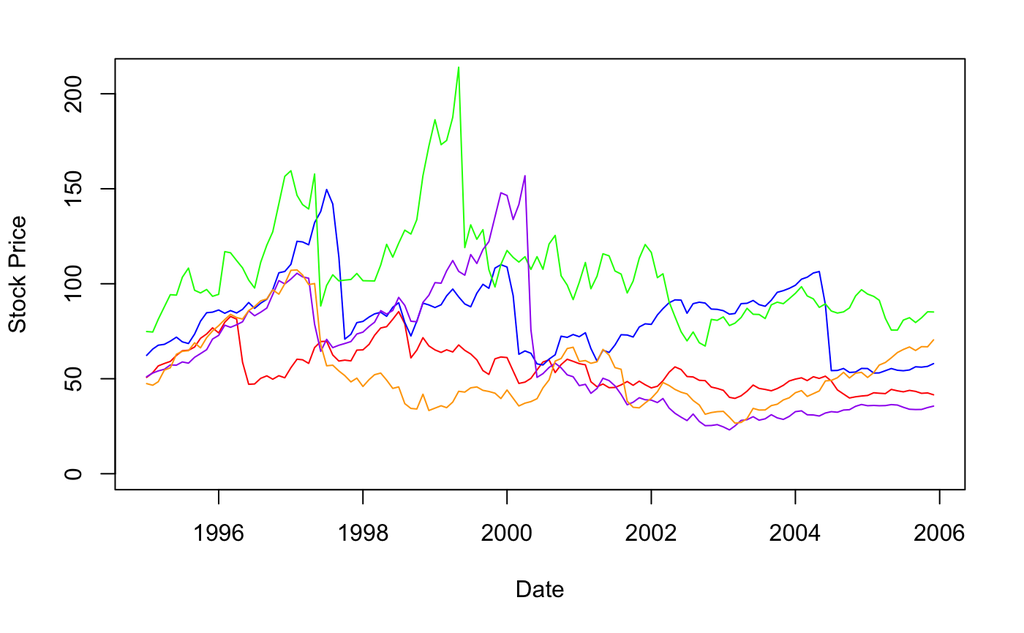

```r
lines(Boeing$Date[301:432], Boeing$StockPrice[301:432], col="orange")
```

General Electric

# Problem 3.2 - Visualizing Stock Dynamics 1995-2005

Which stock reaches the highest value in the time period 1995-2005? IBM

# Problem 3.3 - Visualizing Stock Dynamics 1995-2005

In October of 1997, there was a global stock market crash that was caused by an economic crisis in Asia. Comparing September 1997 to November 1997, which companies saw a decreasing trend in their stock price? (Select all that apply.)

```r
plot(CocaCola$Date[301:432], CocaCola$StockPrice[301:432], type="l", col="red", ylim=c(0,210), xlab = "Date", ylab = "Stock Price")
lines(ProcterGamble$Date[301:432], ProcterGamble$StockPrice[301:432], col="blue")
```

```r
lines(IBM$Date[301:432], IBM$StockPrice[301:432], col="green")
lines(GE$Date[301:432], GE$StockPrice[301:432], col="purple")
```

```r
lines(Boeing$Date[301:432], Boeing$StockPrice[301:432], col="orange")
abline(v=as.Date(c("1997-09-01")), lwd=2)
```

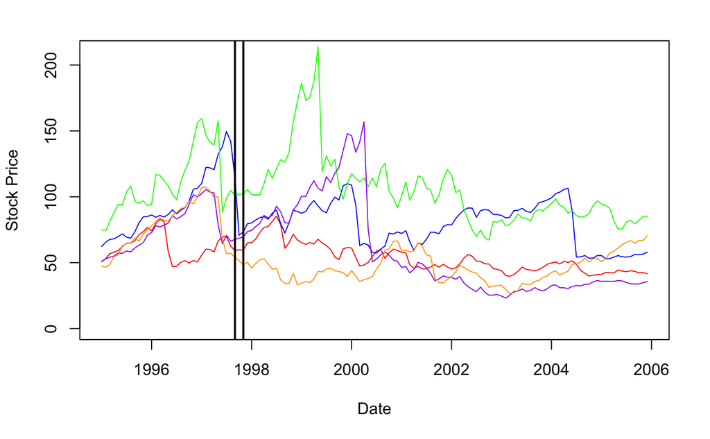

```r
abline(v=as.Date(c("1997-11-01")), lwd=2)
```

# Problem 3.4 - Visualizing Stock Dynamics 1995-2005

In the last two years of this time period (2004 and 2005) which stock seems to be performing the best, in terms of increasing stock price?

```r
plot(CocaCola$Date[301:432], CocaCola$StockPrice[301:432], type="l", col="red", ylim=c(0,210), xlab = "Date", ylab = "Stock Price")
lines(ProcterGamble$Date[301:432], ProcterGamble$StockPrice[301:432], col="blue")
```

```r
lines(IBM$Date[301:432], IBM$StockPrice[301:432], col="green")
lines(GE$Date[301:432], GE$StockPrice[301:432], col="purple")
```

```r
lines(Boeing$Date[301:432], Boeing$StockPrice[301:432], col="orange")
abline(v=as.Date(c("2004-01-01")), lwd=2)
```

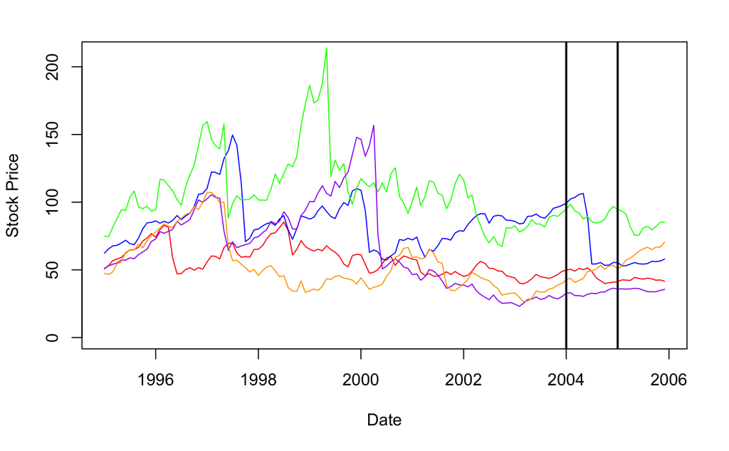

```r
abline(v=as.Date(c("2005-01-01")), lwd=2)
```

Boeing

# Problem 4.1 - Monthly Trends

For IBM, compare the monthly averages to the overall average stock price. In which months has IBM historically had a higher stock price (on average)? Select all that apply.

```r
mean(IBM$StockPrice)
```

```
[1] 144.375
```

```r
tapply(IBM$StockPrice, months(IBM$Date), mean)
```

```
    April    August  December  February   January      July      June     March       May  November   October September
 152.1168  140.1455  140.7593  152.6940  150.2384  139.0670  139.0907  152.4327  151.5022  138.0187  137.3466  139.0885
```

# Problem 4.2 - Monthly Trends

```r
mean(CocaCola$StockPrice)
```

```
[1] 60.02973
```

```r
tapply(CocaCola$StockPrice, months(CocaCola$Date), mean)
```

```
    April    August  December  February   January      July      June     March       May  November   October September
 62.68888  58.88014  59.73223  60.73475  60.36849  58.98346  60.81208  62.07135  61.44358  59.10268  57.93887  57.60024
```

# Problem 4.3 - Monthly Trends

For the months of December and January, every company’s average stock is higher in one month and lower in the other. In which month are the stock prices lower?

```r
tapply(GE$StockPrice, months(GE$Date), mean)
```

```
    April    August  December  February   January      July      June     March       May  November   October September
 64.48009  56.50315  59.10217  62.52080  62.04511  56.73349  56.46844  63.15055  60.87135  57.28879  56.23897  56.23913
```

```r
tapply(CocaCola$StockPrice, months(CocaCola$Date), mean)
```

```
    April    August  December  February   January      July      June     March       May  November   October September
 62.68888  58.88014  59.73223  60.73475  60.36849  58.98346  60.81208  62.07135  61.44358  59.10268  57.93887  57.60024
```

```r
tapply(IBM$StockPrice, months(IBM$Date), mean)
```

```
    April    August  December  February   January      July      June     March       May  November   October September
 152.1168  140.1455  140.7593  152.6940  150.2384  139.0670  139.0907  152.4327  151.5022  138.0187  137.3466  139.0885
```

```r
tapply(ProcterGamble$StockPrice, months(ProcterGamble$Date), mean)
```

```
    April    August  December  February   January      July      June     March       May  November   October September
 77.68671  76.82266  78.29661  79.02575  79.61798  76.64556  77.39275  77.34761  77.85958  78.45610  76.67903  76.62385
```

```r
tapply(Boeing$StockPrice, months(Boeing$Date), mean)
```

```
    April    August  December  February   January      July      June     March       May  November   October September
 47.04686  46.86311  46.17315  46.89223  46.51097  46.55360  47.38525  46.88208  48.13716  45.14990  45.21603  46.30485
```